# Fifa_Overall

Adam Johnson

12/20/2021

## Linear Regression to Predict FIFA Player Overalls

In this code I will be building a linear model to attempt to player rankings from the video game Fifa. The data set used is provided here: https://www.kaggle.com/karangadiya/fifa19

```r
# Loading the Data and Removing any NAs
fifa <- read.csv("fifa_data.csv")
fifa <- na.omit(fifa)
```

## Overview of the data

```r
# Summary Stats of all of the Columns
head(fifa)
```

```
##   ï..     ID              Name Age Nationality Overall Potential
## 1   0 158023          L. Messi  31   Argentina      94        94
## 2   1  20801 Cristiano Ronaldo  33    Portugal      94        94
## 3   2 190871         Neymar Jr  26      Brazil      92        93
## 4   3 193080            De Gea  27       Spain      91        93
## 5   4 192985      K. De Bruyne  27     Belgium      91        92
## 6   5 183277         E. Hazard  27     Belgium      91        91
##                  Club Preferred.Foot International.Reputation Weak.Foot
## 1        FC Barcelona           Left                        5         4
## 2            Juventus          Right                        5         4
## 3 Paris Saint-Germain          Right                        5         5
## 4   Manchester United          Right                        4         3
## 5     Manchester City          Right                        4         5
## 6             Chelsea          Right                        4         4
##   Skill.Moves Height Weight Crossing Finishing HeadingAccuracy ShortPassing
```

[output cut: 41 more lines]

```r
summary(fifa)
```

```
##       ï..              ID             Name                Age
##  Min.   :    0   Min.   :    16   Length:18159       Min.   :16.00
##  1st Qu.: 4540   1st Qu.:200300   Class :character   1st Qu.:21.00
##  Median : 9079   Median :221743   Mode  :character   Median :25.00
##  Mean   : 9092   Mean   :214280                      Mean   :25.12
##  3rd Qu.:13666   3rd Qu.:236509                      3rd Qu.:28.00
##  Max.   :18206   Max.   :246620                      Max.   :45.00
##  Nationality           Overall        Potential         Club
##  Length:18159       Min.   :46.00   Min.   :48.00   Length:18159
##  Class :character   1st Qu.:62.00   1st Qu.:67.00   Class :character
##  Mode  :character   Median :66.00   Median :71.00   Mode  :character
##                     Mean   :66.25   Mean   :71.32
##                     3rd Qu.:71.00   3rd Qu.:75.00
##                     Max.   :94.00   Max.   :95.00
##  Preferred.Foot     International.Reputation   Weak.Foot      Skill.Moves
##  Length:18159       Min.   :1.000            Min.   :1.000   Min.   :1.000
##  Class :character   1st Qu.:1.000            1st Qu.:3.000   1st Qu.:2.000
##  Mode  :character   Median :1.000            Median :3.000   Median :2.000
##                     Mean   :1.113            Mean   :2.947   Mean   :2.361
##                     3rd Qu.:1.000            3rd Qu.:3.000   3rd Qu.:3.000
##                     Max.   :5.000            Max.   :5.000   Max.   :5.000
##     Height             Weight             Crossing       Finishing
##  Length:18159       Length:18159       Min.   : 5.00   Min.   : 2.00
##  Class :character   Class :character   1st Qu.:38.00   1st Qu.:30.00
##  Mode  :character   Mode  :character   Median :54.00   Median :49.00
##                                        Mean   :49.73   Mean   :45.55
##                                        3rd Qu.:64.00   3rd Qu.:62.00
##                                        Max.   :93.00   Max.   :95.00
##  HeadingAccuracy  ShortPassing      Volleys        Dribbling
##  Min.   : 4.0    Min.   : 7.00   Min.   : 4.00   Min.   : 4.00
##  1st Qu.:44.0    1st Qu.:54.00   1st Qu.:30.00   1st Qu.:49.00
##  Median :56.0    Median :62.00   Median :44.00   Median :61.00
##  Mean   :52.3    Mean   :58.69   Mean   :42.91   Mean   :55.37
##  3rd Qu.:64.0    3rd Qu.:68.00   3rd Qu.:57.00   3rd Qu.:68.00
##  Max.   :94.0    Max.   :93.00   Max.   :90.00   Max.   :97.00
##      Curve         FKAccuracy     LongPassing     BallControl
##  Min.   : 6.00   Min.   : 3.00   Min.   : 9.00   Min.   : 5.00
##  1st Qu.:34.00   1st Qu.:31.00   1st Qu.:43.00   1st Qu.:54.00
##  Median :48.00   Median :41.00   Median :56.00   Median :63.00
##  Mean   :47.17   Mean   :42.86   Mean   :52.71   Mean   :58.37
```

[output cut: 29 more lines]

```
##  Max.   :92.00   Max.   :96.00   Max.   :94.00   Max.   :93.0   Max.   :91.00
##     GKDiving       GKHandling      GKKicking     GKPositioning
##  Min.   : 1.00   Min.   : 1.00   Min.   : 1.00   Min.   : 1.00
##  1st Qu.: 8.00   1st Qu.: 8.00   1st Qu.: 8.00   1st Qu.: 8.00
##  Median :11.00   Median :11.00   Median :11.00   Median :11.00
##  Mean   :16.62   Mean   :16.39   Mean   :16.23   Mean   :16.39
##  3rd Qu.:14.00   3rd Qu.:14.00   3rd Qu.:14.00   3rd Qu.:14.00
##  Max.   :90.00   Max.   :92.00   Max.   :91.00   Max.   :90.00
##    GKReflexes
##  Min.   : 1.00
##  1st Qu.: 8.00
##  Median :11.00
##  Mean   :16.71
##  3rd Qu.:14.00
##  Max.   :94.00
```

As I will be attempting to predict Overall, I created the below histogram to get a better sense of how the data is distributed.

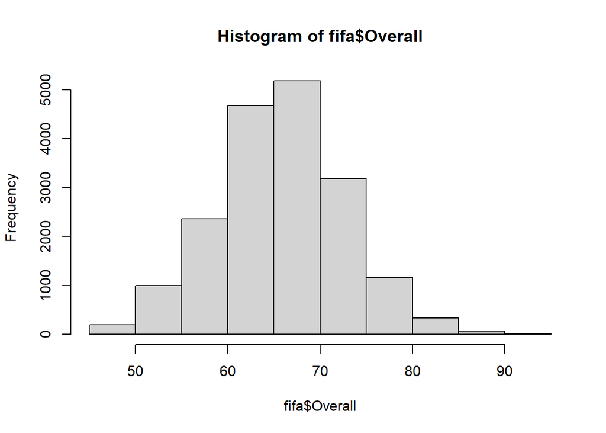

```r
# Creates histogram of the Dependent Variable
hist(fifa$Overall)
```

It appears that the variable that I will be trying to predict is normally distributed.

Next, I went in and selected only the Numeric Columns that I will be using as predictors. I also removed ID columns and columns related to Goal Keeping stats, as they are irrelevant to the majority of players.

```r
# Selecting Just the Numeric Columns
num_column <- unlist(lapply(fifa, is.numeric))
num_fifa <- fifa[ ,num_column]

# Also removing Identification Columns along with columns related to GK
num_fifa <- subset(num_fifa, select = -c(ID, ï.., GKPositioning,GKDiving,GKReflexes, GKHandling, GKKicking))

head(num_fifa)
```

```
##   Age Overall Potential International.Reputation Weak.Foot Skill.Moves Crossing
## 1  31      94        94                        5         4           4       84
## 2  33      94        94                        5         4           5       84
## 3  26      92        93                        5         5           5       79
## 4  27      91        93                        4         3           1       17
## 5  27      91        92                        4         5           4       93
## 6  27      91        91                        4         4           4       81
##   Finishing HeadingAccuracy ShortPassing Volleys Dribbling Curve FKAccuracy
## 1        95              70           90      86        97    93         94
## 2        94              89           81      87        88    81         76
## 3        87              62           84      84        96    88         87
## 4        13              21           50      13        18    21         19
## 5        82              55           92      82        86    85         83
## 6        84              61           89      80        95    83         79
##   LongPassing BallControl Acceleration SprintSpeed Agility Reactions Balance
```

[output cut: 20 more lines]

## Visualizations

I used the code below to make scatter plots of all of the variables put against Overall ranking. This can help to visualize which of the relationships are linear.

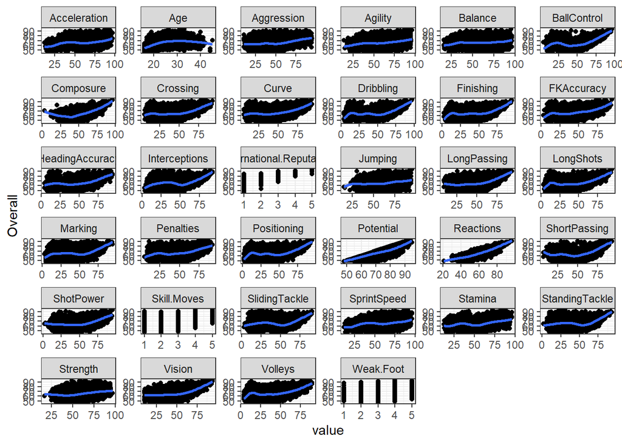

```r
# Generates scatter plots of all of the variables against Overall
library("dplyr")
library("ggplot2")
library("tidyverse")
num_fifa %>%
  gather(-Overall, key = "var", value = "value") %>%
  ggplot(aes(x = value, y = Overall)) +
  geom_point() +
  stat_smooth() +
  facet_wrap(~ var, scales = "free") +
  theme_bw()
```

Next, I wanted to check for correlations between the variables. This can help to get an idea of which predictors to use in the model.

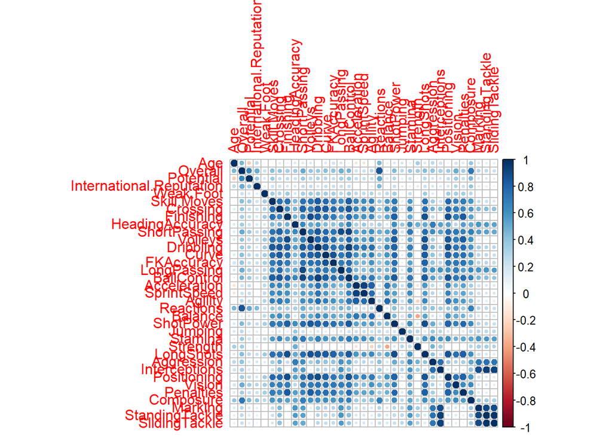

```r
# Code to visually check for correlations
library(corrplot)
correlations <- cor(num_fifa)
corrplot(correlations, method="circle")
```

As there appear to be many correlations between the different variables, I will start the modeling with all of the variables included, and adjust from there.

## Partitioning Data

Before training the model, I will create two data sets. One for training and one for testing the resulting model.

```r
# Creates training and test data
set.seed(100)  # setting seed to reproduce results of random sampling
trainingRow <- sample(1:nrow(num_fifa), 0.8*nrow(num_fifa))
trainingData <- num_fifa[trainingRow, ]
testData  <- num_fifa[-trainingRow, ]
```

## Modeling

For the first attempt at the model, I went in and used all of the available predictors. This is the base line from which the model can be adjusted in future iterations.

```r
# Creates the first model.
fifa_model <- lm(Overall ~ ., data = trainingData)
# Creates summary of the model to review the metrics.
summary(fifa_model)
```

```
##
## Call:
## lm(formula = Overall ~ ., data = trainingData)
##
## Residuals:
##      Min       1Q   Median       3Q      Max
## -10.1563  -1.2447   0.1982   1.3890   7.0327
##
## Coefficients:
##                            Estimate Std. Error t value Pr(>|t|)
## (Intercept)              -1.400e+01  3.508e-01 -39.910  < 2e-16 ***
## Age                       6.195e-01  6.396e-03  96.847  < 2e-16 ***
## Potential                 6.135e-01  4.840e-03 126.753  < 2e-16 ***
## International.Reputation  3.783e-01  5.188e-02   7.291 3.22e-13 ***
## Weak.Foot                -1.908e-02  2.853e-02  -0.669 0.503658
## Skill.Moves               5.219e-01  4.543e-02  11.488  < 2e-16 ***
## Crossing                  1.902e-02  2.350e-03   8.092 6.33e-16 ***
## Finishing                 3.888e-03  2.904e-03   1.339 0.180728
## HeadingAccuracy          -1.263e-02  2.185e-03  -5.782 7.51e-09 ***
## ShortPassing              1.770e-02  4.136e-03   4.280 1.88e-05 ***
## Volleys                  -6.268e-03  2.545e-03  -2.463 0.013784 *
## Dribbling                -1.883e-02  3.680e-03  -5.115 3.18e-07 ***
## Curve                     3.677e-03  2.520e-03   1.459 0.144546
## FKAccuracy               -5.178e-03  2.223e-03  -2.330 0.019837 *
## LongPassing               1.141e-02  3.038e-03   3.755 0.000174 ***
## BallControl               1.737e-02  4.397e-03   3.949 7.87e-05 ***
## Acceleration              1.207e-02  3.459e-03   3.490 0.000484 ***
## SprintSpeed               2.504e-02  3.200e-03   7.827 5.36e-15 ***
## Agility                   5.253e-04  2.564e-03   0.205 0.837697
## Reactions                 2.125e-01  3.494e-03  60.803  < 2e-16 ***
## Balance                  -3.049e-02  2.289e-03 -13.322  < 2e-16 ***
## ShotPower                 1.084e-02  2.593e-03   4.182 2.91e-05 ***
## Jumping                   1.308e-02  1.797e-03   7.277 3.58e-13 ***
## Stamina                   2.702e-02  2.108e-03  12.820  < 2e-16 ***
## Strength                  3.626e-02  2.188e-03  16.574  < 2e-16 ***
## LongShots                 6.057e-03  2.746e-03   2.206 0.027410 *
## Aggression               -1.080e-02  1.925e-03  -5.610 2.06e-08 ***
## Interceptions            -2.558e-03  2.811e-03  -0.910 0.362750
## Positioning              -3.350e-02  2.726e-03 -12.289  < 2e-16 ***
## Vision                    1.865e-04  2.490e-03   0.075 0.940294
## Penalties                -2.509e-02  2.403e-03 -10.444  < 2e-16 ***
## Composure                 4.449e-02  2.853e-03  15.594  < 2e-16 ***
## Marking                  -4.336e-03  2.220e-03  -1.953 0.050820 .
## StandingTackle            5.643e-03  4.207e-03   1.341 0.179851
## SlidingTackle            -2.034e-02  3.898e-03  -5.218 1.83e-07 ***
## ---
## Signif. codes:  0 '***' 0.001 '**' 0.01 '*' 0.05 '.' 0.1 ' ' 1
##
## Residual standard error: 2.078 on 14492 degrees of freedom
## Multiple R-squared:  0.9102, Adjusted R-squared:   0.91
## F-statistic:  4322 on 34 and 14492 DF,  p-value: < 2.2e-16
```

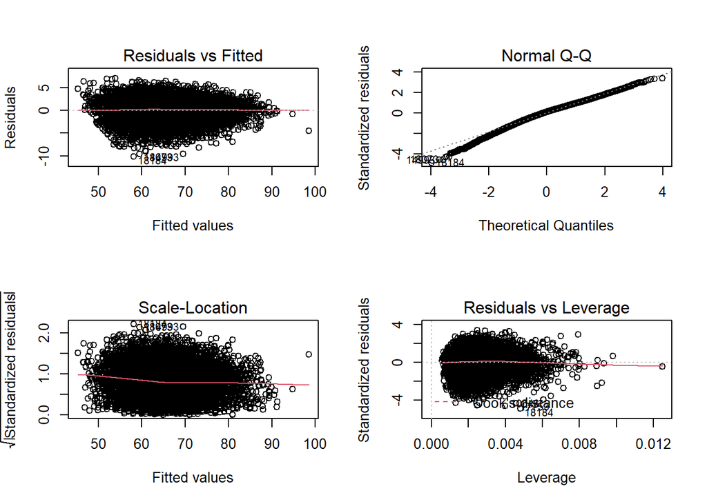

```r
# Creates plots of the model to be used for validation purposes.
par(mfrow = c(2,2))
plot(fifa_model)
```

```r
# Removing Non-significant Coefficients to compare to previous model.
trainingData <- subset(trainingData, select = -c(Weak.Foot, Curve, FKAccuracy, Agility, LongShots, Interceptions, Vision, Marking, StandingTackle))
```

```r
# Second rendition of the model, this time will all of the non-significant coefficients removed.
fifa_model2 <- lm(Overall ~ ., data = trainingData)
summary(fifa_model2)
```

```
##
## Call:
## lm(formula = Overall ~ ., data = trainingData)
##
## Residuals:
##      Min       1Q   Median       3Q      Max
## -10.1241  -1.2420   0.2014   1.3904   7.0439
##
## Coefficients:
##                            Estimate Std. Error t value Pr(>|t|)
## (Intercept)              -14.030893   0.344955 -40.675  < 2e-16 ***
## Age                        0.618411   0.006352  97.350  < 2e-16 ***
## Potential                  0.613305   0.004823 127.168  < 2e-16 ***
## International.Reputation   0.374074   0.051801   7.221 5.40e-13 ***
## Skill.Moves                0.521091   0.044995  11.581  < 2e-16 ***
## Crossing                   0.019132   0.002220   8.617  < 2e-16 ***
## Finishing                  0.005830   0.002765   2.108 0.035012 *
## HeadingAccuracy           -0.013328   0.002039  -6.538 6.45e-11 ***
## ShortPassing               0.017272   0.004119   4.193 2.77e-05 ***
## Volleys                   -0.005359   0.002464  -2.175 0.029678 *
## Dribbling                 -0.017541   0.003644  -4.814 1.49e-06 ***
## LongPassing                0.011386   0.002906   3.918 8.97e-05 ***
## BallControl                0.016958   0.004372   3.879 0.000105 ***
## Acceleration               0.012364   0.003378   3.660 0.000253 ***
## SprintSpeed                0.024992   0.003169   7.886 3.35e-15 ***
## Reactions                  0.212476   0.003440  61.765  < 2e-16 ***
## Balance                   -0.030628   0.002202 -13.910  < 2e-16 ***
## ShotPower                  0.012963   0.002320   5.586 2.36e-08 ***
## Jumping                    0.013251   0.001777   7.459 9.22e-14 ***
## Stamina                    0.026748   0.002066  12.944  < 2e-16 ***
## Strength                   0.036400   0.002168  16.789  < 2e-16 ***
## Aggression                -0.011026   0.001900  -5.805 6.58e-09 ***
## Positioning               -0.032700   0.002671 -12.244  < 2e-16 ***
## Penalties                 -0.025873   0.002316 -11.169  < 2e-16 ***
## Composure                  0.044465   0.002829  15.715  < 2e-16 ***
## SlidingTackle             -0.020087   0.001770 -11.351  < 2e-16 ***
## ---
## Signif. codes:  0 '***' 0.001 '**' 0.01 '*' 0.05 '.' 0.1 ' ' 1
##
## Residual standard error: 2.078 on 14501 degrees of freedom
## Multiple R-squared:  0.9101, Adjusted R-squared:   0.91
## F-statistic:  5875 on 25 and 14501 DF,  p-value: < 2.2e-16
```

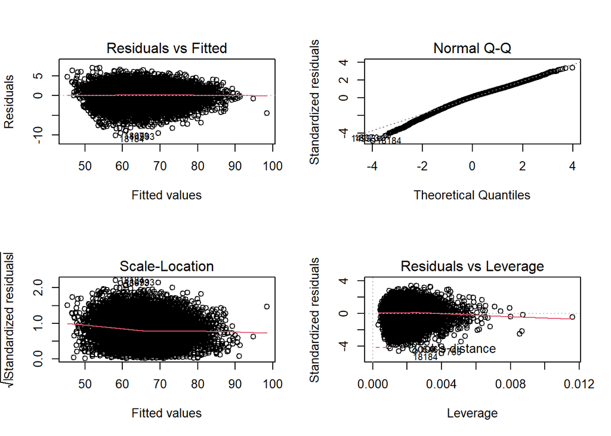

```r
par(mfrow = c(2,2))
plot(fifa_model2)
```

New model has improved F-Statistics, while all other attributes are the same. All coefficients are now significant.

To see if the model can be improved any more, I also removed the two coefficients with the lowest levels of significance. As we can see from the previous model summary, these two coefficients are Finishing and Volleys.

```r
# Removing lowest significance to see if any improvement
trainingData <- subset(trainingData, select = -c(Finishing, Volleys))
```

Now that all of the selected variables have been removed, it is time to once again run the model.

```r
# Third rendition of the model.
fifa_model3 <- lm(Overall ~ ., data = trainingData)
summary(fifa_model3)
```

```
##
## Call:
## lm(formula = Overall ~ ., data = trainingData)
##
## Residuals:
##      Min       1Q   Median       3Q      Max
## -10.0983  -1.2411   0.2021   1.3883   7.0381
##
## Coefficients:
##                            Estimate Std. Error t value Pr(>|t|)
## (Intercept)              -14.034049   0.344780 -40.704  < 2e-16 ***
## Age                        0.618445   0.006353  97.346  < 2e-16 ***
## Potential                  0.613864   0.004818 127.407  < 2e-16 ***
## International.Reputation   0.364045   0.051643   7.049 1.88e-12 ***
## Skill.Moves                0.517587   0.044818  11.549  < 2e-16 ***
## Crossing                   0.018516   0.002209   8.383  < 2e-16 ***
## HeadingAccuracy           -0.013254   0.002025  -6.547 6.08e-11 ***
## ShortPassing               0.017184   0.004120   4.171 3.05e-05 ***
## Dribbling                 -0.017069   0.003621  -4.713 2.46e-06 ***
## LongPassing                0.011492   0.002906   3.955 7.70e-05 ***
## BallControl                0.017358   0.004367   3.975 7.08e-05 ***
## Acceleration               0.012250   0.003379   3.626 0.000289 ***
## SprintSpeed                0.025197   0.003169   7.952 1.97e-15 ***
## Reactions                  0.212131   0.003438  61.697  < 2e-16 ***
## Balance                   -0.030685   0.002201 -13.940  < 2e-16 ***
## ShotPower                  0.012783   0.002172   5.885 4.07e-09 ***
## Jumping                    0.013245   0.001776   7.456 9.45e-14 ***
## Stamina                    0.026984   0.002065  13.068  < 2e-16 ***
## Strength                   0.036579   0.002167  16.879  < 2e-16 ***
## Aggression                -0.011328   0.001895  -5.978 2.32e-09 ***
## Positioning               -0.031481   0.002456 -12.817  < 2e-16 ***
## Penalties                 -0.025835   0.002200 -11.745  < 2e-16 ***
## Composure                  0.044062   0.002822  15.614  < 2e-16 ***
## SlidingTackle             -0.020643   0.001646 -12.540  < 2e-16 ***
## ---
## Signif. codes:  0 '***' 0.001 '**' 0.01 '*' 0.05 '.' 0.1 ' ' 1
##
## Residual standard error: 2.079 on 14503 degrees of freedom
## Multiple R-squared:  0.9101, Adjusted R-squared:   0.91
## F-statistic:  6383 on 23 and 14503 DF,  p-value: < 2.2e-16
```

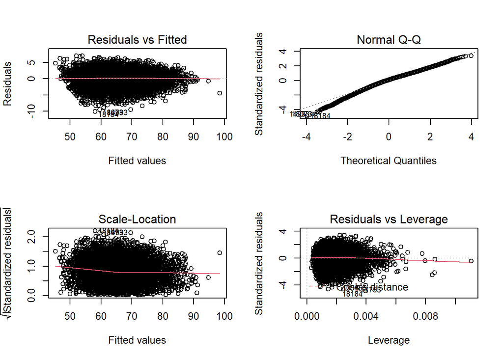

```r
par(mfrow = c(2,2))
plot(fifa_model3)
```

## Predictions

Now that the model has been chosen, it is time to actually make predictions with the model.

```r
# Creates the predictions and saves in predictions variable
predictions <- round(predict(fifa_model3, trainingData),0)

# Creates data frame of predictions and actual values
actuals_preds <- data.frame(cbind(actuals=trainingData$Overall, predicteds=predictions))
head(actuals_preds)
```

```
##       actuals predicteds
## 16935      56         60
## 3430       72         70
## 3696       72         72
## 3052       73         74
## 11159      64         62
## 8192       67         70
```

```r
# Takes correlation between the actual values and the predicted values
cor_accuracy <- cor(actuals_preds)
cor_accuracy
```

```
##              actuals predicteds
## actuals    1.0000000  0.9530797
## predicteds 0.9530797  1.0000000
```

```r
# Calculates min max accuracy of the predictions. The closer to 1, the better the model is performing.
min_max_accuracy <- mean(apply(actuals_preds, 1, min) / apply(actuals_preds, 1, max))
min_max_accuracy
```

```
## [1] 0.9756779
```

When running the model on the training data, it is clear that the model is performing very well. The correlation between the actual values and the predictions is approximately 95%. This indicates that the predictions are very close to the actual values. The calculated min max value is .9757, which also indicates that the model is performing very strongly.

Finally, to confirm that this model is working well, I did the same predictions on the test data. This is to check to see if there is any over fitting, and if the model can still perform well on a data set that it was not trained on.

```r
# Running Model on Testing data to see if there is any over fitting

predictions <- round(predict(fifa_model3, testData),0)

actuals_preds <- data.frame(cbind(actuals=testData$Overall, predicteds=predictions))
head(actuals_preds)
```

```
##    actuals predicteds
## 3       92         91
## 6       91         89
## 12      90         88
## 17      89         86
## 21      89         87
## 39      88         88
```

```r
cor_accuracy <- cor(actuals_preds)
cor_accuracy
```

```
##              actuals predicteds
## actuals    1.0000000  0.9529231
## predicteds 0.9529231  1.0000000
```

```r
min_max_accuracy <- mean(apply(actuals_preds, 1, min) / apply(actuals_preds, 1, max))
min_max_accuracy
```

```
## [1] 0.9758522
```

The predictions on the test data resulted in nearly identical correlations and min max values. Because of this, we can say that there does not appear to be a risk of over fitting.